# Exercise week 5

Shawn Schneidereit

2021-05-20

### 5H4

Here is an open practice problem to engage your imagination. In the divorce date, States in the southern United States have many of the highest divorce rates. Add the South indicator variable to the analysis. First, draw one or more DAGs that represent your ideas for how Southern American culture might influence any of the other three variables (D, M or A). Then list the testable implications of your DAGs, if there are any, and fit one or more models to evaluate the implications. What do you think the influence of “Southerness” is?

```r
# load data and copy
library(rethinking)
data(WaffleDivorce)
d <- WaffleDivorce
# standardize variables
d$Divorce <- standardize( d$Divorce )
d$Marriage <- standardize( d$Marriage )
d$MedianAgeMarriage <- standardize( d$MedianAgeMarriage )
```

Here I have S influencing both marriage and divorce rate. For marriage I expect stronger conservative and religious values to increase the rate marriage rates, as their are stronger stigmas towards absences before marriage as well as un-wed couples having children. For the divorce rates, I expect the south to be a proxy for poorer socioeconomic development and weaker institutions, which increase household stress and thus the chance of relationship breakdown.

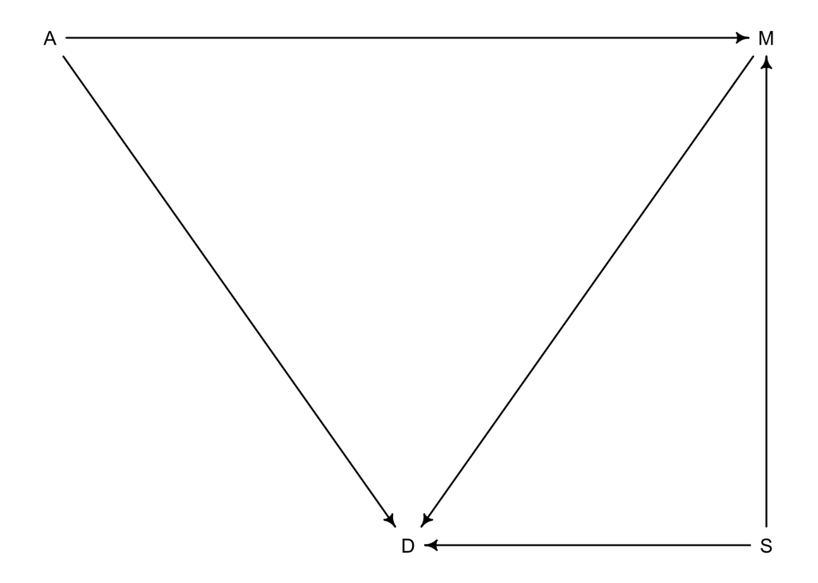

```r
library(dagitty)
dag <- dagitty( "dag{ A -> D; A -> M; M -> D; S -> M; S -> D}" )
coordinates(dag) <- list( x=c(A=0,D=1,M=2, S=2) , y=c(A=0,D=1,M=0, S=1) )
drawdag( dag )
```

```r
# impliedConditionalIndependencies 1 where marriage has no influence on divorce
DMA_dag1 <- dagitty('dag{ D <- A -> M ; D <- S -> M}')
impliedConditionalIndependencies( DMA_dag1 )
```

```
## A _||_ S
## D _||_ M | A, S
```

```r
# impliedConditionalIndependencies 1 where marriage has  influence on divorce
DMA_dag2 <- dagitty('dag{ D <- A -> M -> D; D <- S -> M}')
impliedConditionalIndependencies( DMA_dag2 )
```

```
## A _||_ S
```

```r
# model

d <- d %>% mutate(South = as.factor(South))
str(d)
```

```
## 'data.frame':    50 obs. of  13 variables:
##  $ Location         : Factor w/ 50 levels "Alabama","Alaska",..: 1 2 3 4 5 6 7 8 9 10 ...
##  $ Loc              : Factor w/ 50 levels "AK","AL","AR",..: 2 1 4 3 5 6 7 9 8 10 ...
##  $ Population       : num  4.78 0.71 6.33 2.92 37.25 ...
##  $ MedianAgeMarriage: num  -0.606 -0.687 -0.204 -1.41 0.6 ...
##   ..- attr(*, "scaled:center")= num 26.1
##   ..- attr(*, "scaled:scale")= num 1.24
##  $ Marriage         : num  0.0226 1.5498 0.049 1.6551 -0.267 ...
##   ..- attr(*, "scaled:center")= num 20.1
##   ..- attr(*, "scaled:scale")= num 3.8
##  $ Marriage.SE      : num  1.27 2.93 0.98 1.7 0.39 1.24 1.06 2.89 2.53 0.58 ...
##  $ Divorce          : num  1.654 1.544 0.611 2.094 -0.927 ...
##   ..- attr(*, "scaled:center")= num 9.69
##   ..- attr(*, "scaled:scale")= num 1.82
##  $ Divorce.SE       : num  0.79 2.05 0.74 1.22 0.24 0.94 0.77 1.39 1.89 0.32 ...
##  $ WaffleHouses     : int  128 0 18 41 0 11 0 3 0 133 ...
##  $ South            : Factor w/ 2 levels "0","1": 2 1 1 2 1 1 1 1 1 2 ...
##  $ Slaves1860       : int  435080 0 0 111115 0 0 0 1798 0 61745 ...
##  $ Population1860   : int  964201 0 0 435450 379994 34277 460147 112216 75080 140424 ...
##  $ PropSlaves1860   : num  0.45 0 0 0.26 0 0 0 0.016 0 0.44 ...
```

```r
b5H4 <- brm(data = d,
      family = gaussian,
      Divorce ~ 1 + South + Marriage + MedianAgeMarriage,
      prior = c(prior(normal(0, 0.2), class = Intercept),
                prior(normal(0, 0.5), class = b),
                prior(exponential(1), class = sigma)),
      iter = 2000, warmup = 1000, chains = 4,
      seed = 42)
```

```
## Trying to compile a simple C file
```

[output not shown]

```r
summary(b5H4)
```

```
##  Family: gaussian
##   Links: mu = identity; sigma = identity
## Formula: Divorce ~ 1 + South + Marriage + MedianAgeMarriage
##    Data: d (Number of observations: 50)
## Samples: 4 chains, each with iter = 2000; warmup = 1000; thin = 1;
##          total post-warmup samples = 4000
##
## Population-Level Effects:
##                   Estimate Est.Error l-95% CI u-95% CI Rhat Bulk_ESS Tail_ESS
## Intercept            -0.10      0.12    -0.33     0.13 1.00     4613     2987
## South1                0.37      0.23    -0.08     0.83 1.00     4445     2663
## Marriage             -0.04      0.16    -0.35     0.27 1.00     2909     2400
## MedianAgeMarriage    -0.55      0.16    -0.87    -0.23 1.00     3015     2738
##
## Family Specific Parameters:
##       Estimate Est.Error l-95% CI u-95% CI Rhat Bulk_ESS Tail_ESS
## sigma     0.81      0.08     0.66     0.99 1.00     3822     2789
##
## Samples were drawn using sampling(NUTS). For each parameter, Bulk_ESS
## and Tail_ESS are effective sample size measures, and Rhat is the potential
## scale reduction factor on split chains (at convergence, Rhat = 1).
```

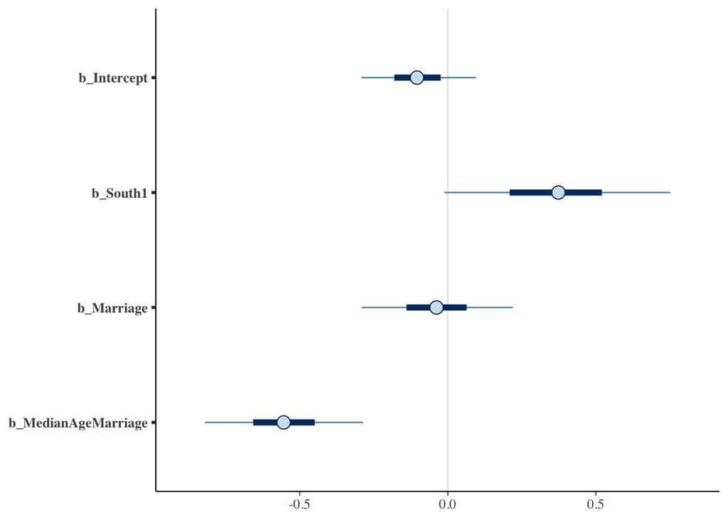

```r
mcmc_plot(b5H4, pars = "^b_")
```

Based on the Model, I believe that southerness increases the rate of divorce, (although it is notable that there is a wide est.error and CI). While a reasonably strong predictor when compared to the marriage rate, which essentially has no influence, overall age at marriage still has the strongest influence on the divorce rate.